# Лабораторная работа Вариант 11. Q1136LF

## Пряников О.Р. БЗК204

## 2023-11-24

```python
#Импорт библиотек

import csv
import pandas as pd
import numpy as np
import math
import scipy.stats as st
import itertools as it
import numpy.matlib as nm
import matplotlib as mpl
import matplotlib.pyplot as plt
```

Скачиваем данные о вероятности умереть в возрасте от 0 до 100 для Самарской области, Сельской местности, Женщин.

```python
Q1136LF = pd.read_excel(io='Data_life_2022.xls',sheet_name='Q1136LF',
                 usecols = 'A:E', header=None, names=['q_1994', 'q_2007', 'q_2013', 'q_2016', 'q_2020'])
Q1136LF.head(101)
```

|  | q_1994 | q_2007 | q_2013 | q_2016 | q_2020 |
| --- | --- | --- | --- | --- | --- |
| 0 | 0.01085 | 0.006361 | 0.007379 | 0.005532 | 0.002268 |
| 1 | 0.00167 | 0.000339 | 0.000553 | 0.000255 | 0.000117 |
| 2 | 0.00076 | 0.000339 | 0.000553 | 0.000255 | 0.000117 |
| 3 | 0.00071 | 0.000339 | 0.000553 | 0.000255 | 0.000117 |
| 4 | 0.00043 | 0.000339 | 0.000179 | 0.000255 | 0.000117 |
| ... | ... | ... | ... | ... | ... |
| 96 | 0.37812 | 0.391419 | 0.347168 | 0.289529 | 0.228137 |
| 97 | 0.40882 | 0.391419 | 0.318238 | 0.250049 | 0.183333 |
| 98 | 0.44105 | 0.391419 | 0.385251 | 0.351416 | 0.360000 |
| 99 | 0.47468 | 0.391419 | 0.385251 | 0.181855 | 0.135136 |
| 100 | 0.50956 | 1.000000 | 1.000000 | 1.000000 | 1.000000 |

101 rows × 5 columns

```python
Q1136LF.describe()
```

|  | q_1994 | q_2007 | q_2013 | q_2016 | q_2020 |
| --- | --- | --- | --- | --- | --- |
| count | 101.000000 | 101.000000 | 101.000000 | 101.000000 | 101.000000 |
| mean | 0.062742 | 0.064835 | 0.056751 | 0.050427 | 0.050453 |
| std | 0.116252 | 0.138611 | 0.130270 | 0.121694 | 0.119398 |
| min | 0.000140 | 0.000339 | 0.000179 | 0.000160 | 0.000117 |
| 25% | 0.001390 | 0.002268 | 0.001203 | 0.001276 | 0.000318 |
| 50% | 0.007730 | 0.006361 | 0.005811 | 0.005004 | 0.005977 |
| 75% | 0.056420 | 0.049804 | 0.040284 | 0.040534 | 0.043170 |
| max | 0.509560 | 1.000000 | 1.000000 | 1.000000 | 1.000000 |

Добавляем переменную возраста (age) в таблицу смертности

```python
age = list(range(0,101))
Q1136LF.insert(loc=0, column='age', value= age)
Q1136LF.head()
```

|  | age | q_1994 | q_2007 | q_2013 | q_2016 | q_2020 |
| --- | --- | --- | --- | --- | --- | --- |
| 0 | 0 | 0.01085 | 0.006361 | 0.007379 | 0.005532 | 0.002268 |
| 1 | 1 | 0.00167 | 0.000339 | 0.000553 | 0.000255 | 0.000117 |
| 2 | 2 | 0.00076 | 0.000339 | 0.000553 | 0.000255 | 0.000117 |
| 3 | 3 | 0.00071 | 0.000339 | 0.000553 | 0.000255 | 0.000117 |
| 4 | 4 | 0.00043 | 0.000339 | 0.000179 | 0.000255 | 0.000117 |

Построим график Вероятности умереть в данном возрасте для всех 5 годов

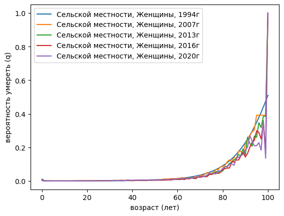

```python
plt.plot(Q1136LF.age, Q1136LF.q_1994, label='Сельской местности, Женщины, 1994г')
plt.plot(Q1136LF.age,Q1136LF.q_2007, label='Сельской местности, Женщины, 2007г')
plt.plot(Q1136LF.age,Q1136LF.q_2013, label='Сельской местности, Женщины, 2013г')
plt.plot(Q1136LF.age,Q1136LF.q_2016, label='Сельской местности, Женщины, 2016г')
plt.plot(Q1136LF.age,Q1136LF.q_2020, label='Сельской местности, Женщины, 2020г')
plt.legend()
plt.xlabel('возраст (лет)')
plt.ylabel('вероятность умереть (q)')
plt.show()
```

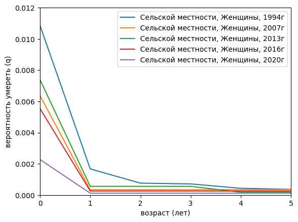

```python
plt.plot(Q1136LF.age, Q1136LF.q_1994, label='Сельской местности, Женщины, 1994г')
plt.plot(Q1136LF.age,Q1136LF.q_2007, label='Сельской местности, Женщины, 2007г')
plt.plot(Q1136LF.age,Q1136LF.q_2013, label='Сельской местности, Женщины, 2013г')
plt.plot(Q1136LF.age,Q1136LF.q_2016, label='Сельской местности, Женщины, 2016г')
plt.plot(Q1136LF.age,Q1136LF.q_2020, label='Сельской местности, Женщины, 2020г')
plt.legend()
plt.xlabel('возраст (лет)')
plt.ylabel('вероятность умереть (q)')
plt.xlim(0,5)
plt.ylim(0,0.012)
plt.show()
```

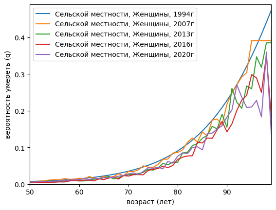

```python
plt.plot(Q1136LF.age, Q1136LF.q_1994, label='Сельской местности, Женщины, 1994г')
plt.plot(Q1136LF.age,Q1136LF.q_2007, label='Сельской местности, Женщины, 2007г')
plt.plot(Q1136LF.age,Q1136LF.q_2013, label='Сельской местности, Женщины, 2013г')
plt.plot(Q1136LF.age,Q1136LF.q_2016, label='Сельской местности, Женщины, 2016г')
plt.plot(Q1136LF.age,Q1136LF.q_2020, label='Сельской местности, Женщины, 2020г')
plt.legend()
plt.xlabel('возраст (лет)')
plt.ylabel('вероятность умереть (q)')
plt.xlim(50,99)
plt.ylim(0,0.49)
plt.show()
```

Для дальнейшего анализа добавим в таблицу данные о числе доживающих до возраста x (l), числе смертей в возрасте x (d), полной средней продолжительности жизни для возраста x (e) для всех годов

```python
q_1994 = list(Q1136LF.q_1994)
l_1994 = [100000,]
d_1994 = []
e_1994 = []


for i in range(0,101):
    d_1994.append(round(l_1994[i]*q_1994[i]))
    l_1994.append(round(l_1994[i]-d_1994[i]))

for i in range(0,101):
    e_1994.append((sum(l_1994[i+1:])/l_1994[i])+0.5)

l_1994.pop(-1) #послкольку последнее число списка должно равняться нулю его необходимо удалить,
#а так как скорее всего для 1994 года таблица сметртности не ограничивалась предельным возрастом в 100 лет
#это число больше нуля, однако оно не является интерпретируемым и его также следует удалить
```

```
54
```

```python
q_2007 = list(Q1136LF.q_2007)
l_2007 = [100000,]
d_2007 = []
e_2007 = []


for i in range(0,101):
    d_2007.append(round(l_2007[i]*q_2007[i]))
    l_2007.append(round(l_2007[i]-d_2007[i]))

for i in range(0,101):
    e_2007.append((sum(l_2007[i+1:])/l_2007[i])+0.5)

l_2007.pop(-1)
```

```
0
```

```python
q_2013 = list(Q1136LF.q_2013)
l_2013 = [100000,]
d_2013 = []
e_2013 = []


for i in range(0,101):
    d_2013.append(round(l_2013[i]*q_2013[i]))
    l_2013.append(round(l_2013[i]-d_2013[i]))

for i in range(0,101):
    e_2013.append((sum(l_2013[i+1:])/l_2013[i])+0.5)

l_2013.pop(-1)
```

```
0
```

```python
q_2016 = list(Q1136LF.q_2016)
l_2016 = [100000,]
d_2016 = []
e_2016 = []

for i in range(0,101):
    d_2016.append(round(l_2016[i]*q_2016[i]))
    l_2016.append(round(l_2016[i]-d_2016[i]))

for i in range(0,101):
    e_2016.append((sum(l_2016[i+1:])/l_2016[i])+0.5)

l_2016.pop(-1)
```

```
0
```

```python
q_2020 = list(Q1136LF.q_2020)
l_2020 = [100000,]
d_2020 = []
e_2020 = []

for i in range(0,101):
    d_2020.append(round(l_2020[i]*q_2020[i]))
    l_2020.append(round(l_2020[i]-d_2020[i]))

for i in range(0,101):
    e_2020.append((sum(l_2020[i+1:])/l_2020[i])+0.5)



l_2020.pop(-1)
```

```
0
```

Добавляем новые переменные в таблицу смертности

```python
Q1136LF.insert(loc=1, column='d_1994', value= d_1994)
Q1136LF.insert(loc=1, column='l_1994', value= l_1994)
Q1136LF.insert(loc=4, column='e_1994', value= e_1994)
```

```python
Q1136LF.insert(loc=5, column='d_2007', value= d_2007)
Q1136LF.insert(loc=5, column='l_2007', value= l_2007)
Q1136LF.insert(loc=8, column='e_2007', value= e_2007)
```

```python
Q1136LF.insert(loc=9, column='d_2013', value= d_2013)
Q1136LF.insert(loc=9, column='l_2013', value= l_2013)
Q1136LF.insert(loc=12, column='e_2013', value= e_2013)
```

```python
Q1136LF.insert(loc=13, column='d_2016', value= d_2016)
Q1136LF.insert(loc=13, column='l_2016', value= l_2016)
Q1136LF.insert(loc=16, column='e_2016', value= e_2016)
```

```python
Q1136LF.insert(loc=17, column='d_2020', value= d_2020)
Q1136LF.insert(loc=17, column='l_2020', value= l_2020)
Q1136LF.insert(loc=20, column='e_2020', value= e_2020)
```

```python
Q1136LF.head(101)
```

|  | age | l_1994 | d_1994 | q_1994 | e_1994 | l_2007 | d_2007 | q_2007 | e_2007 | l_2013 | ... | q_2013 | e_2013 | l_2016 | d_2016 | q_2016 | e_2016 | l_2020 | d_2020 | q_2020 | e_2020 |
| --- | --- | --- | --- | --- | --- | --- | --- | --- | --- | --- | --- | --- | --- | --- | --- | --- | --- | --- | --- | --- | --- |
| 0 | 0 | 100000 | 1085 | 0.01085 | 71.900870 | 100000 | 636 | 0.006361 | 72.040310 | 100000 | ... | 0.007379 | 74.919360 | 100000 | 553 | 0.005532 | 76.165070 | 100000 | 227 | 0.002268 | 75.128110 |
| 1 | 1 | 98915 | 165 | 0.00167 | 71.684067 | 99364 | 34 | 0.000339 | 71.498219 | 99262 | ... | 0.000553 | 74.472658 | 99447 | 25 | 0.000255 | 75.585825 | 99773 | 12 | 0.000117 | 74.297901 |
| 2 | 2 | 98750 | 75 | 0.00076 | 70.803008 | 99330 | 34 | 0.000339 | 70.522521 | 99207 | ... | 0.000553 | 73.513668 | 99422 | 25 | 0.000255 | 74.604705 | 99761 | 12 | 0.000117 | 73.306778 |
| 3 | 3 | 98675 | 70 | 0.00071 | 69.856443 | 99296 | 34 | 0.000339 | 69.546497 | 99152 | ... | 0.000553 | 72.554169 | 99397 | 25 | 0.000255 | 73.623344 | 99749 | 12 | 0.000117 | 72.315537 |
| 4 | 4 | 98605 | 42 | 0.00043 | 68.905679 | 99262 | 34 | 0.000339 | 68.570148 | 99097 | ... | 0.000179 | 71.594160 | 99372 | 25 | 0.000255 | 72.641740 | 99737 | 12 | 0.000117 | 71.324178 |
| ... | ... | ... | ... | ... | ... | ... | ... | ... | ... | ... | ... | ... | ... | ... | ... | ... | ... | ... | ... | ... | ... |
| 96 | 96 | 1022 | 386 | 0.37812 | 1.856164 | 1191 | 466 | 0.391419 | 1.840890 | 2763 | ... | 0.347168 | 2.039993 | 3792 | 1098 | 0.289529 | 2.371308 | 3183 | 726 | 0.228137 | 2.654571 |
| 97 | 97 | 636 | 260 | 0.40882 | 1.679245 | 725 | 284 | 0.391419 | 1.702759 | 1804 | ... | 0.318238 | 1.858647 | 2694 | 674 | 0.250049 | 2.134001 | 2457 | 450 | 0.183333 | 2.291209 |
| 98 | 98 | 376 | 166 | 0.44105 | 1.494681 | 441 | 173 | 0.391419 | 1.477324 | 1230 | ... | 0.385251 | 1.492683 | 2020 | 710 | 0.351416 | 1.679208 | 2007 | 723 | 0.360000 | 1.692825 |
| 99 | 99 | 210 | 100 | 0.47468 | 1.280952 | 268 | 105 | 0.391419 | 1.108209 | 756 | ... | 0.385251 | 1.115079 | 1310 | 238 | 0.181855 | 1.318321 | 1284 | 174 | 0.135136 | 1.364486 |
| 100 | 100 | 110 | 56 | 0.50956 | 0.990909 | 163 | 163 | 1.000000 | 0.500000 | 465 | ... | 1.000000 | 0.500000 | 1072 | 1072 | 1.000000 | 0.500000 | 1110 | 1110 | 1.000000 | 0.500000 |

101 rows × 21 columns

```python
Q1136LF.to_excel(excel_writer = "Q1136LF.xlsx", index=False)
```

Построим кривую смертности в данном возрасте для всех 5 годов

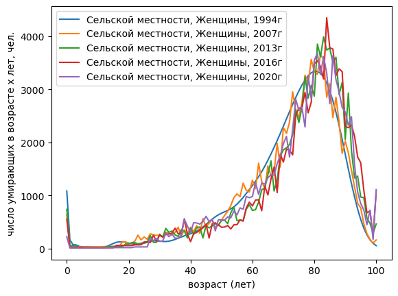

```python
plt.plot(Q1136LF.age,Q1136LF.d_1994, label='Сельской местности, Женщины, 1994г')
plt.plot(Q1136LF.age,Q1136LF.d_2007, label='Сельской местности, Женщины, 2007г')
plt.plot(Q1136LF.age,Q1136LF.d_2013, label='Сельской местности, Женщины, 2013г')
plt.plot(Q1136LF.age,Q1136LF.d_2016, label='Сельской местности, Женщины, 2016г')
plt.plot(Q1136LF.age,Q1136LF.d_2020, label='Сельской местности, Женщины, 2020г')
plt.legend()
plt.xlabel('возраст (лет)')
plt.ylabel('число умирающих в возрасте х лет, чел.')
plt.show()
```

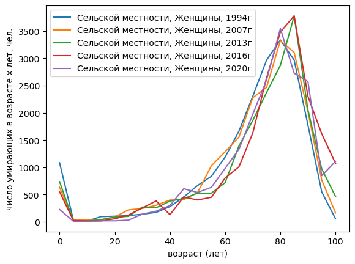

```python
plt.plot(Q1136LF.age[::5],Q1136LF.d_1994[::5], label='Сельской местности, Женщины, 1994г')
plt.plot(Q1136LF.age[::5],Q1136LF.d_2007[::5], label='Сельской местности, Женщины, 2007г')
plt.plot(Q1136LF.age[::5],Q1136LF.d_2013[::5], label='Сельской местности, Женщины, 2013г')
plt.plot(Q1136LF.age[::5],Q1136LF.d_2016[::5], label='Сельской местности, Женщины, 2016г')
plt.plot(Q1136LF.age[::5],Q1136LF.d_2020[::5], label='Сельской местности, Женщины, 2020г')
plt.legend()
plt.xlabel('возраст (лет)')
plt.ylabel('число умирающих в возрасте х лет, чел.')
plt.show()
```

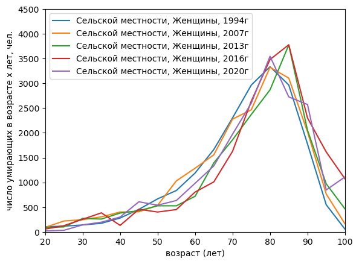

```python
plt.plot(Q1136LF.age[::5],Q1136LF.d_1994[::5], label='Сельской местности, Женщины, 1994г')
plt.plot(Q1136LF.age[::5],Q1136LF.d_2007[::5], label='Сельской местности, Женщины, 2007г')
plt.plot(Q1136LF.age[::5],Q1136LF.d_2013[::5], label='Сельской местности, Женщины, 2013г')
plt.plot(Q1136LF.age[::5],Q1136LF.d_2016[::5], label='Сельской местности, Женщины, 2016г')
plt.plot(Q1136LF.age[::5],Q1136LF.d_2020[::5], label='Сельской местности, Женщины, 2020г')
plt.legend()
plt.xlabel('возраст (лет)')
plt.ylabel('число умирающих в возрасте х лет, чел.')
plt.xlim(20,100)
plt.ylim(0,4500)
plt.show()
```

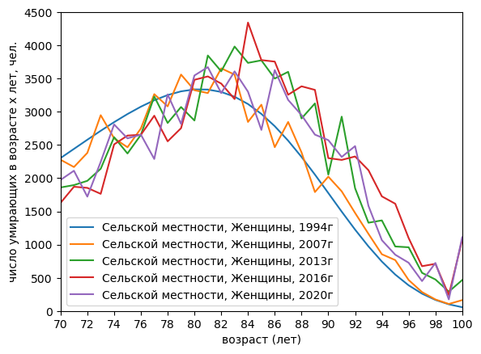

```python
plt.plot(Q1136LF.age,Q1136LF.d_1994, label='Сельской местности, Женщины, 1994г')
plt.plot(Q1136LF.age,Q1136LF.d_2007, label='Сельской местности, Женщины, 2007г')
plt.plot(Q1136LF.age,Q1136LF.d_2013, label='Сельской местности, Женщины, 2013г')
plt.plot(Q1136LF.age,Q1136LF.d_2016, label='Сельской местности, Женщины, 2016г')
plt.plot(Q1136LF.age,Q1136LF.d_2020, label='Сельской местности, Женщины, 2020г')
plt.xticks(np.arange(min(Q1136LF.age), max(Q1136LF.age)+1, 2))
plt.legend()
plt.xlabel('возраст (лет)')
plt.ylabel('число умирающих в возрасте х лет, чел.')
plt.xlim(70,100)
plt.ylim(0,4500)
plt.show()
```

Построим график Вероятности умереть в данном возрасте для 2020 года для определения возрастного интервал исследования

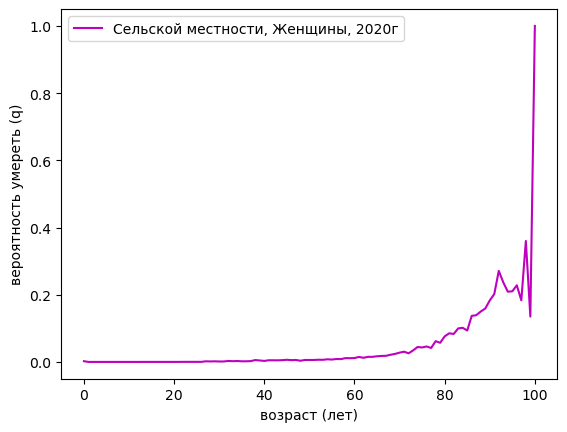

```python
plt.plot(Q1136LF.age,Q1136LF.q_2020, label='Сельской местности, Женщины, 2020г', color = 'm')
plt.legend()
plt.xlabel('возраст (лет)')
plt.ylabel('вероятность умереть (q)')
#plt.xlim(50,99)
#plt.ylim(0,0.49)
plt.show()
```

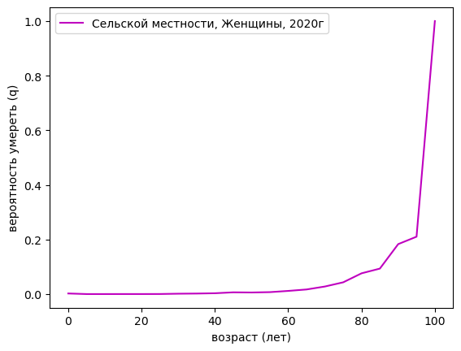

```python
plt.plot(Q1136LF.age[::5],Q1136LF.q_2020[::5], label='Сельской местности, Женщины, 2020г', color = 'm')
plt.legend()
plt.xlabel('возраст (лет)')
plt.ylabel('вероятность умереть (q)')
#plt.xlim(50,99)
#plt.ylim(0,0.49)
plt.show()
```

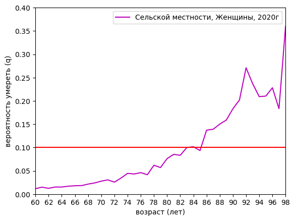

```python
plt.plot(Q1136LF.age,Q1136LF.q_2020, label='Сельской местности, Женщины, 2020г', color = 'm')
plt.legend()
plt.xticks(np.arange(min(Q1136LF.age), max(Q1136LF.age)+1, 2))
plt.xlabel('возраст (лет)')
plt.ylabel('вероятность умереть (q)')
plt.hlines(y=0.1,xmin=60,xmax=98, color = 'r')
#plt.vlines(x=83,ymin=0,ymax=1, color = 'r')
plt.xlim(60,98)
plt.ylim(0,0.4)
plt.show()
```

Строим кривую дожития и функцию распределения продолжительности предстоящей жизни для данных 2020 года

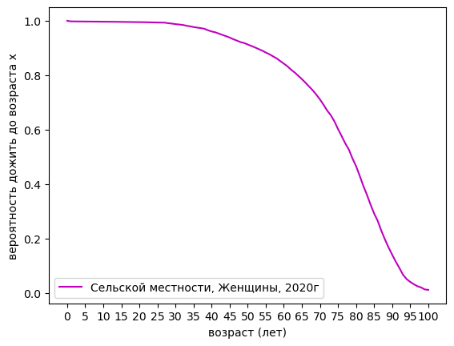

```python
plt.plot(Q1136LF.age,Q1136LF.l_2020/100000, label='Сельской местности, Женщины, 2020г', color = 'm')
plt.legend()
plt.xticks(np.arange(min(Q1136LF.age), max(Q1136LF.age)+1, 5))
plt.xlabel('возраст (лет)')
plt.ylabel('вероятность дожить до возраста x')
#plt.hlines(y=0.1,xmin=60,xmax=98, color = 'r')
#plt.vlines(x=83,ymin=0,ymax=1, color = 'r')
#plt.xlim(60,98)
#plt.ylim(0,0.4)
plt.show()
```

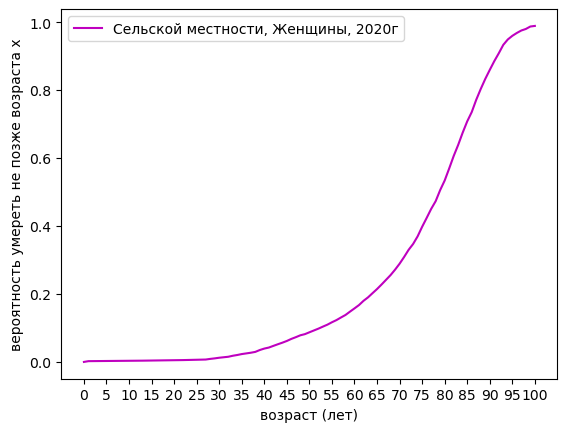

```python
plt.plot(Q1136LF.age,1-Q1136LF.l_2020/100000, label='Сельской местности, Женщины, 2020г', color = 'm')
plt.legend()
plt.xticks(np.arange(min(Q1136LF.age), max(Q1136LF.age)+1, 5))
plt.xlabel('возраст (лет)')
plt.ylabel('вероятность умереть не позже возраста x')
plt.show()
```

Аналогично вероятности умереть в возрасте от 0 до 100 для Самарской области, Сельской местности, Женщин, скачвиваем данные для всей России и Сельской местности, Женщин и состовляем две таблицы смертности для них

```python
Q = pd.read_excel(io='Data_life_2022.xls',sheet_name='Q',
                 usecols = 'A:E', header=None, names=['q_2007', 'q_2013', 'q_2016', 'q_2019', 'q_2020'])
Q.head(101)
```

|  | q_2007 | q_2013 | q_2016 | q_2019 | q_2020 |
| --- | --- | --- | --- | --- | --- |
| 0 | 0.009354 | 0.008158 | 0.006020 | 0.004873 | 0.004491 |
| 1 | 0.000933 | 0.000689 | 0.000564 | 0.000464 | 0.000421 |
| 2 | 0.000635 | 0.000421 | 0.000338 | 0.000272 | 0.000260 |
| 3 | 0.000477 | 0.000358 | 0.000283 | 0.000228 | 0.000212 |
| 4 | 0.000437 | 0.000288 | 0.000246 | 0.000196 | 0.000162 |
| ... | ... | ... | ... | ... | ... |
| 96 | 0.289051 | 0.265960 | 0.245610 | 0.215315 | 0.237239 |
| 97 | 0.312857 | 0.281530 | 0.286945 | 0.213724 | 0.230210 |
| 98 | 0.352869 | 0.297307 | 0.271027 | 0.173530 | 0.217108 |
| 99 | 0.315132 | 0.293629 | 0.236412 | 0.180677 | 0.158754 |
| 100 | 1.000000 | 1.000000 | 1.000000 | 1.000000 | 1.000000 |

101 rows × 5 columns

```python
del Q['q_2007'] #удаляем данные для 2007 и 2013 года, так как они не понадабяться для анализа
del Q['q_2013']
```

```python
age = list(range(0,101))
Q.insert(loc=0, column='age', value= age)
Q.head(101)
```

|  | age | q_2016 | q_2019 | q_2020 |
| --- | --- | --- | --- | --- |
| 0 | 0 | 0.006020 | 0.004873 | 0.004491 |
| 1 | 1 | 0.000564 | 0.000464 | 0.000421 |
| 2 | 2 | 0.000338 | 0.000272 | 0.000260 |
| 3 | 3 | 0.000283 | 0.000228 | 0.000212 |
| 4 | 4 | 0.000246 | 0.000196 | 0.000162 |
| ... | ... | ... | ... | ... |
| 96 | 96 | 0.245610 | 0.215315 | 0.237239 |
| 97 | 97 | 0.286945 | 0.213724 | 0.230210 |
| 98 | 98 | 0.271027 | 0.173530 | 0.217108 |
| 99 | 99 | 0.236412 | 0.180677 | 0.158754 |
| 100 | 100 | 1.000000 | 1.000000 | 1.000000 |

101 rows × 4 columns

```python
q_2016 = list(Q.q_2016)
l_2016 = [100000,]
d_2016 = []
e_2016 = []

for i in range(0,101):
    d_2016.append(round(l_2016[i]*q_2016[i]))
    l_2016.append(round(l_2016[i]-d_2016[i]))

for i in range(0,101):
    e_2016.append((sum(l_2016[i+1:])/l_2016[i])+0.5)

l_2016.pop(-1)
```

```
0
```

```python
q_2019 = list(Q.q_2019)
l_2019 = [100000,]
d_2019 = []
e_2019 = []


for i in range(0,101):
    d_2019.append(round(l_2019[i]*q_2019[i]))
    l_2019.append(round(l_2019[i]-d_2013[i]))

for i in range(0,101):
    e_2019.append((sum(l_2019[i+1:])/l_2019[i])+0.5)

l_2019.pop(-1)
```

```
0
```

```python
q_2020 = list(Q.q_2020)
l_2020 = [100000,]
d_2020 = []
e_2020 = []

for i in range(0,101):
    d_2020.append(round(l_2020[i]*q_2020[i]))
    l_2020.append(round(l_2020[i]-d_2020[i]))

for i in range(0,101):
    e_2020.append((sum(l_2020[i+1:])/l_2020[i])+0.5)

l_2020.pop(-1)
```

```
0
```

```python
Q.insert(loc=1, column='d_2016', value= d_2016)
Q.insert(loc=1, column='l_2016', value= l_2016)
Q.insert(loc=4, column='e_2016', value= e_2016)
```

```python
Q.insert(loc=5, column='d_2019', value= d_2019)
Q.insert(loc=5, column='l_2019', value= l_2019)
Q.insert(loc=8, column='e_2019', value= e_2019)
```

```python
Q.insert(loc=9, column='d_2020', value= d_2020)
Q.insert(loc=9, column='l_2020', value= l_2020)
Q.insert(loc=12, column='e_2020', value= e_2020)
```

```python
Q.head(101)
```

|  | age | l_2016 | d_2016 | q_2016 | e_2016 | l_2019 | d_2019 | q_2019 | e_2019 | l_2020 | d_2020 | q_2020 | e_2020 |
| --- | --- | --- | --- | --- | --- | --- | --- | --- | --- | --- | --- | --- | --- |
| 0 | 0 | 100000 | 602 | 0.006020 | 71.861720 | 100000 | 487 | 0.004873 | 74.919360 | 100000 | 449 | 0.004491 | 71.527160 |
| 1 | 1 | 99398 | 56 | 0.000564 | 71.293919 | 99262 | 46 | 0.000464 | 74.472658 | 99551 | 42 | 0.000421 | 70.847510 |
| 2 | 2 | 99342 | 34 | 0.000338 | 70.333827 | 99207 | 27 | 0.000272 | 73.513668 | 99509 | 26 | 0.000260 | 69.877202 |
| 3 | 3 | 99308 | 28 | 0.000283 | 69.357736 | 99152 | 23 | 0.000228 | 72.554169 | 99483 | 21 | 0.000212 | 68.895334 |
| 4 | 4 | 99280 | 24 | 0.000246 | 68.377156 | 99097 | 19 | 0.000196 | 71.594160 | 99462 | 16 | 0.000162 | 67.909775 |
| ... | ... | ... | ... | ... | ... | ... | ... | ... | ... | ... | ... | ... | ... |
| 96 | 96 | 2685 | 659 | 0.245610 | 2.484358 | 2763 | 595 | 0.215315 | 2.039993 | 2019 | 479 | 0.237239 | 2.696137 |
| 97 | 97 | 2026 | 581 | 0.286945 | 2.129812 | 1804 | 386 | 0.213724 | 1.858647 | 1540 | 355 | 0.230210 | 2.379221 |
| 98 | 98 | 1445 | 392 | 0.271027 | 1.785121 | 1230 | 213 | 0.173530 | 1.492683 | 1185 | 257 | 0.217108 | 1.942194 |
| 99 | 99 | 1053 | 249 | 0.236412 | 1.263533 | 756 | 137 | 0.180677 | 1.115079 | 928 | 147 | 0.158754 | 1.341595 |
| 100 | 100 | 804 | 804 | 1.000000 | 0.500000 | 465 | 465 | 1.000000 | 0.500000 | 781 | 781 | 1.000000 | 0.500000 |

101 rows × 13 columns

```python
Q.to_excel(excel_writer = "Q.xlsx", index=False)
```

```python
QLF = pd.read_excel(io='Data_life_2022.xls',sheet_name='QLF',
                 usecols = 'C:E', header=None, names=['q_2016', 'q_2019', 'q_2020'])
QLF.head(101)
```

|  | q_2016 | q_2019 | q_2020 |
| --- | --- | --- | --- |
| 0 | 0.006852 | 0.005155 | 0.004671 |
| 1 | 0.000728 | 0.000643 | 0.000593 |
| 2 | 0.000328 | 0.000392 | 0.000363 |
| 3 | 0.000279 | 0.000247 | 0.000259 |
| 4 | 0.000256 | 0.000243 | 0.000198 |
| ... | ... | ... | ... |
| 96 | 0.273561 | 0.223665 | 0.226972 |
| 97 | 0.330605 | 0.238823 | 0.221036 |
| 98 | 0.306745 | 0.208646 | 0.229558 |
| 99 | 0.276427 | 0.223815 | 0.182090 |
| 100 | 1.000000 | 1.000000 | 1.000000 |

101 rows × 3 columns

```python
age = list(range(0,101))
QLF.insert(loc=0, column='age', value= age)
QLF.head(101)
```

|  | age | q_2016 | q_2019 | q_2020 |
| --- | --- | --- | --- | --- |
| 0 | 0 | 0.006852 | 0.005155 | 0.004671 |
| 1 | 1 | 0.000728 | 0.000643 | 0.000593 |
| 2 | 2 | 0.000328 | 0.000392 | 0.000363 |
| 3 | 3 | 0.000279 | 0.000247 | 0.000259 |
| 4 | 4 | 0.000256 | 0.000243 | 0.000198 |
| ... | ... | ... | ... | ... |
| 96 | 96 | 0.273561 | 0.223665 | 0.226972 |
| 97 | 97 | 0.330605 | 0.238823 | 0.221036 |
| 98 | 98 | 0.306745 | 0.208646 | 0.229558 |
| 99 | 99 | 0.276427 | 0.223815 | 0.182090 |
| 100 | 100 | 1.000000 | 1.000000 | 1.000000 |

101 rows × 4 columns

```python
q_2016 = list(QLF.q_2016)
l_2016 = [100000,]
d_2016 = []
e_2016 = []

for i in range(0,101):
    d_2016.append(round(l_2016[i]*q_2016[i]))
    l_2016.append(round(l_2016[i]-d_2016[i]))

for i in range(0,101):
    e_2016.append((sum(l_2016[i+1:])/l_2016[i])+0.5)

l_2016.pop(-1)
```

```
0
```

```python
q_2019 = list(QLF.q_2019)
l_2019 = [100000,]
d_2019 = []
e_2019 = []


for i in range(0,101):
    d_2019.append(round(l_2019[i]*q_2019[i]))
    l_2019.append(round(l_2019[i]-d_2013[i]))

for i in range(0,101):
    e_2019.append((sum(l_2019[i+1:])/l_2019[i])+0.5)

l_2019.pop(-1)
```

```
0
```

```python
q_2020 = list(QLF.q_2020)
l_2020 = [100000,]
d_2020 = []
e_2020 = []

for i in range(0,101):
    d_2020.append(round(l_2020[i]*q_2020[i]))
    l_2020.append(round(l_2020[i]-d_2020[i]))

for i in range(0,101):
    e_2020.append((sum(l_2020[i+1:])/l_2020[i])+0.5)

l_2020.pop(-1)
```

```
0
```

```python
QLF.insert(loc=1, column='d_2016', value= d_2016)
QLF.insert(loc=1, column='l_2016', value= l_2016)
QLF.insert(loc=4, column='e_2016', value= e_2016)
```

```python
QLF.insert(loc=5, column='d_2019', value= d_2019)
QLF.insert(loc=5, column='l_2019', value= l_2019)
QLF.insert(loc=8, column='e_2019', value= e_2019)
```

```python
QLF.insert(loc=9, column='d_2020', value= d_2020)
QLF.insert(loc=9, column='l_2020', value= l_2020)
QLF.insert(loc=12, column='e_2020', value= e_2020)
```

```python
QLF.head(101)
```

|  | age | l_2016 | d_2016 | q_2016 | e_2016 | l_2019 | d_2019 | q_2019 | e_2019 | l_2020 | d_2020 | q_2020 | e_2020 |
| --- | --- | --- | --- | --- | --- | --- | --- | --- | --- | --- | --- | --- | --- |
| 0 | 0 | 100000 | 685 | 0.006852 | 76.057160 | 100000 | 516 | 0.005155 | 74.919360 | 100000 | 467 | 0.004671 | 75.808190 |
| 1 | 1 | 99315 | 72 | 0.000728 | 75.578296 | 99262 | 64 | 0.000643 | 74.472658 | 99533 | 59 | 0.000593 | 75.161529 |
| 2 | 2 | 99243 | 33 | 0.000328 | 74.632765 | 99207 | 39 | 0.000392 | 73.513668 | 99474 | 36 | 0.000363 | 74.205813 |
| 3 | 3 | 99210 | 28 | 0.000279 | 73.657424 | 99152 | 24 | 0.000247 | 72.554169 | 99438 | 26 | 0.000259 | 73.232497 |
| 4 | 4 | 99182 | 25 | 0.000256 | 72.678077 | 99097 | 24 | 0.000243 | 71.594160 | 99412 | 20 | 0.000198 | 72.251519 |
| ... | ... | ... | ... | ... | ... | ... | ... | ... | ... | ... | ... | ... | ... |
| 96 | 96 | 3540 | 968 | 0.273561 | 2.294350 | 2763 | 618 | 0.223665 | 2.039993 | 3800 | 862 | 0.226972 | 2.719474 |
| 97 | 97 | 2572 | 850 | 0.330605 | 1.969673 | 1804 | 431 | 0.238823 | 1.858647 | 2938 | 649 | 0.221036 | 2.370660 |
| 98 | 98 | 1722 | 528 | 0.306745 | 1.695122 | 1230 | 257 | 0.208646 | 1.492683 | 2289 | 525 | 0.229558 | 1.901048 |
| 99 | 99 | 1194 | 330 | 0.276427 | 1.223618 | 756 | 169 | 0.223815 | 1.115079 | 1764 | 321 | 0.182090 | 1.318027 |
| 100 | 100 | 864 | 864 | 1.000000 | 0.500000 | 465 | 465 | 1.000000 | 0.500000 | 1443 | 1443 | 1.000000 | 0.500000 |

101 rows × 13 columns

```python
QLF.to_excel(excel_writer = "QLF.xlsx", index=False)
```

Сравниваем результаты за 2020 год демографической статистики Самарской области и России в целом, Сельской местности, Женщин

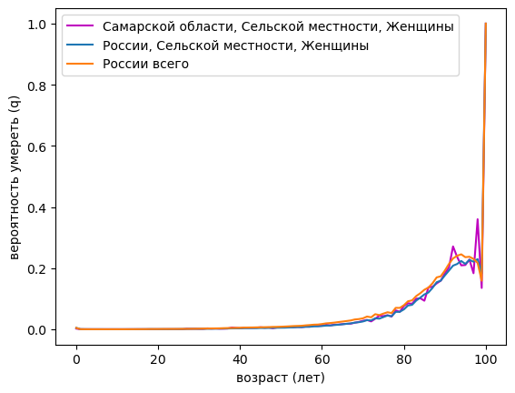

```python
plt.plot(Q1136LF.age, Q1136LF.q_2020, label='Самарской области, Сельской местности, Женщины', color = 'm')
plt.plot(Q1136LF.age,QLF.q_2020, label='России, Сельской местности, Женщины')
plt.plot(Q1136LF.age,Q.q_2020, label='России всего')
plt.legend()
plt.xlabel('возраст (лет)')
plt.ylabel('вероятность умереть (q)')
plt.show()
```

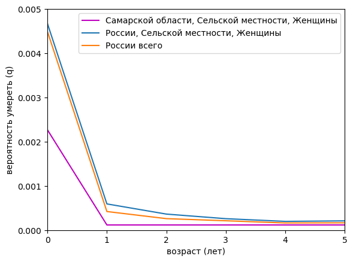

```python
plt.plot(Q1136LF.age, Q1136LF.q_2020, label='Самарской области, Сельской местности, Женщины', color = 'm')
plt.plot(Q1136LF.age,QLF.q_2020, label='России, Сельской местности, Женщины')
plt.plot(Q1136LF.age,Q.q_2020, label='России всего')
plt.legend()
plt.xlabel('возраст (лет)')
plt.ylabel('вероятность умереть (q)')
plt.xlim(0,5)
plt.ylim(0,0.005)
plt.show()
```

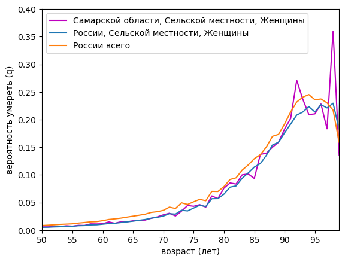

```python
plt.plot(Q1136LF.age, Q1136LF.q_2020, label='Самарской области, Сельской местности, Женщины', color = 'm')
plt.plot(Q1136LF.age,QLF.q_2020, label='России, Сельской местности, Женщины')
plt.plot(Q1136LF.age,Q.q_2020, label='России всего')
plt.legend()
plt.xlabel('возраст (лет)')
plt.ylabel('вероятность умереть (q)')
plt.xticks(np.arange(min(Q1136LF.age), max(Q1136LF.age)+1, 5))
plt.xlim(50,99)
plt.ylim(0,0.4)
plt.show()
```

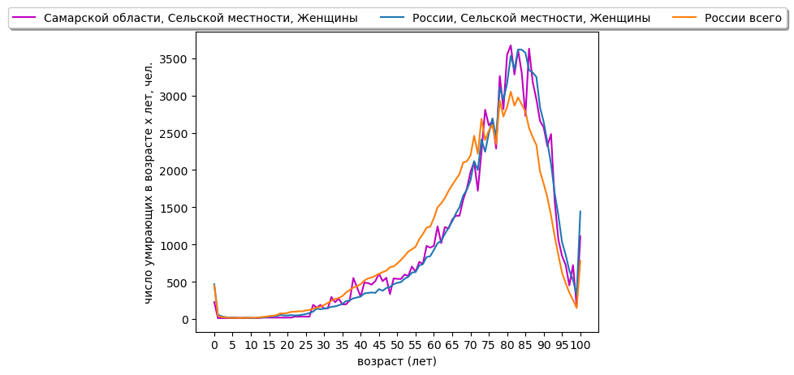

```python
plt.plot(Q1136LF.age, Q1136LF.d_2020, label='Самарской области, Сельской местности, Женщины', color = 'm')
plt.plot(Q1136LF.age,QLF.d_2020, label='России, Сельской местности, Женщины')
plt.plot(Q1136LF.age,Q.d_2020, label='России всего')
plt.legend(loc='upper center', bbox_to_anchor=(0.5, 1.1),ncol=3, fancybox=True, shadow=True)
plt.xticks(np.arange(min(Q1136LF.age), max(Q1136LF.age)+1, 5))
plt.xlabel('возраст (лет)')
plt.ylabel('число умирающих в возрасте х лет, чел.')
plt.show()
```

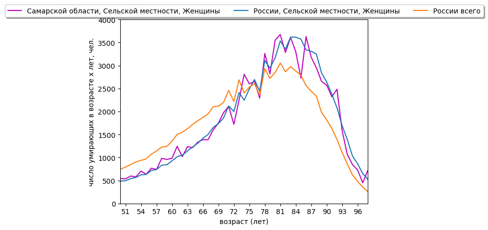

```python
plt.plot(Q1136LF.age, Q1136LF.d_2020, label='Самарской области, Сельской местности, Женщины', color = 'm')
plt.plot(Q1136LF.age,QLF.d_2020, label='России, Сельской местности, Женщины')
plt.plot(Q1136LF.age,Q.d_2020, label='России всего')
plt.legend(loc='upper center', bbox_to_anchor=(0.5, 1.1),ncol=3, fancybox=True, shadow=True)
plt.xticks(np.arange(min(Q1136LF.age), max(Q1136LF.age)+1, 3))
plt.xlabel('возраст (лет)')
plt.ylabel('число умирающих в возрасте х лет, чел.')
plt.xlim(50,98)
plt.ylim(0,4000)
plt.show()
```

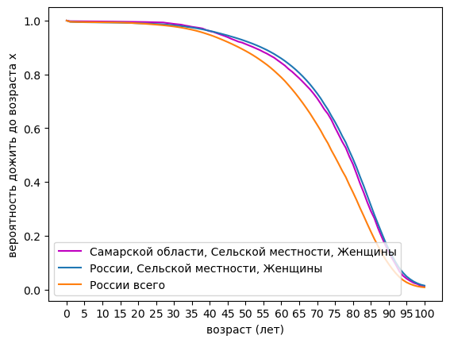

```python
plt.plot(Q1136LF.age,Q1136LF.l_2020/100000, label='Самарской области, Сельской местности, Женщины', color = 'm')
plt.plot(Q1136LF.age,QLF.l_2020/100000, label='России, Сельской местности, Женщины')
plt.plot(Q1136LF.age,Q.l_2020/100000, label='России всего')
plt.legend()
plt.xticks(np.arange(min(Q1136LF.age), max(Q1136LF.age)+1, 5))
plt.xlabel('возраст (лет)')
plt.ylabel('вероятность дожить до возраста x')
plt.show()
```

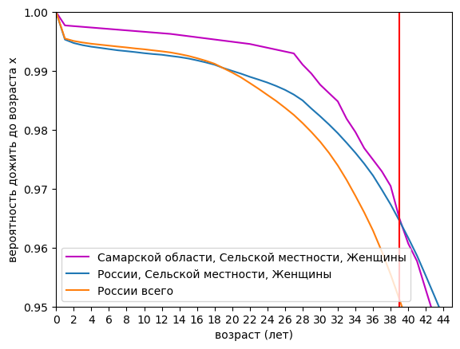

```python
plt.plot(Q1136LF.age,Q1136LF.l_2020/100000, label='Самарской области, Сельской местности, Женщины', color = 'm')
plt.plot(Q1136LF.age,QLF.l_2020/100000, label='России, Сельской местности, Женщины')
plt.plot(Q1136LF.age,Q.l_2020/100000, label='России всего')
plt.legend()
plt.xticks(np.arange(min(Q1136LF.age), max(Q1136LF.age)+1, 2))
plt.xlabel('возраст (лет)')
plt.ylabel('вероятность дожить до возраста x')
plt.vlines(x=39,ymin=0,ymax=1, color = 'r')
plt.xlim(0,45)
plt.ylim(0.95,1)
plt.show()
```

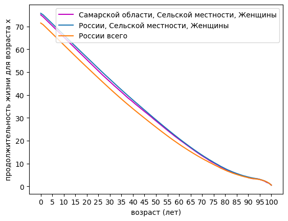

```python
plt.plot(Q1136LF.age,Q1136LF.e_2020, label='Самарской области, Сельской местности, Женщины', color = 'm')
plt.plot(Q1136LF.age,QLF.e_2020, label='России, Сельской местности, Женщины')
plt.plot(Q1136LF.age,Q.e_2020, label='России всего')
plt.legend()
plt.xticks(np.arange(min(Q1136LF.age), max(Q1136LF.age)+1, 5))
plt.xlabel('возраст (лет)')
plt.ylabel('продолжительность жизни для возраста x')
plt.show()
```

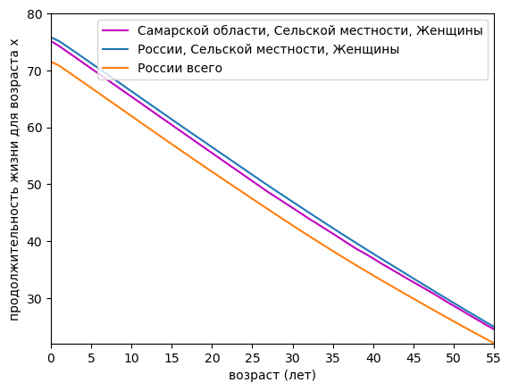

```python
plt.plot(Q1136LF.age,Q1136LF.e_2020, label='Самарской области, Сельской местности, Женщины', color = 'm')
plt.plot(Q1136LF.age,QLF.e_2020, label='России, Сельской местности, Женщины')
plt.plot(Q1136LF.age,Q.e_2020, label='России всего')
plt.legend()
plt.xticks(np.arange(min(Q1136LF.age), max(Q1136LF.age)+1, 5))
plt.xlabel('возраст (лет)')
plt.ylabel('продолжительность жизни для возраста x')
plt.xlim(0,55)
plt.ylim(22,80)
plt.show()
```

Сравнительный анализ статистики по РФ в разные годы с целью изучения влияния пандемии COVID-19

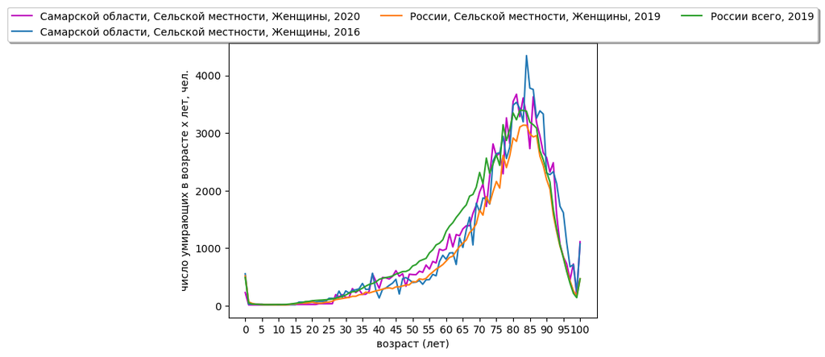

```python
plt.plot(Q1136LF.age, Q1136LF.d_2020, label='Самарской области, Сельской местности, Женщины, 2020', color = 'm')
plt.plot(Q1136LF.age, Q1136LF.d_2016, label='Самарской области, Сельской местности, Женщины, 2016',)
plt.plot(Q1136LF.age,QLF.d_2019, label='России, Сельской местности, Женщины, 2019')
plt.plot(Q1136LF.age,Q.d_2019, label='России всего, 2019')
plt.legend(loc='upper center', bbox_to_anchor=(0.5, 1.15),ncol=3, fancybox=True, shadow=True)
plt.xticks(np.arange(min(Q1136LF.age), max(Q1136LF.age)+1, 5))
plt.xlabel('возраст (лет)')
plt.ylabel('число умирающих в возрасте х лет, чел.')
plt.show()
```

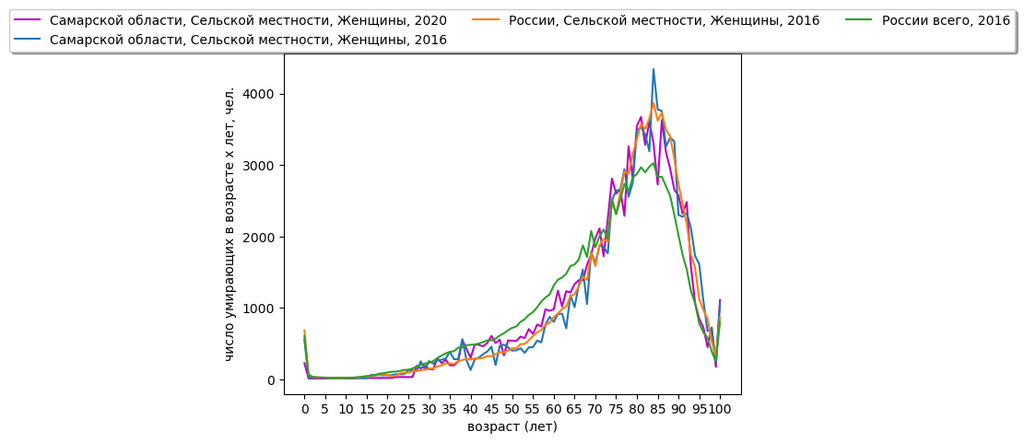

```python
plt.plot(Q1136LF.age, Q1136LF.d_2020, label='Самарской области, Сельской местности, Женщины, 2020', color = 'm')
plt.plot(Q1136LF.age, Q1136LF.d_2016, label='Самарской области, Сельской местности, Женщины, 2016',)
plt.plot(Q1136LF.age,QLF.d_2016, label='России, Сельской местности, Женщины, 2016')
plt.plot(Q1136LF.age,Q.d_2016, label='России всего, 2016')
plt.legend(loc='upper center', bbox_to_anchor=(0.5, 1.15),ncol=3, fancybox=True, shadow=True)
plt.xticks(np.arange(min(Q1136LF.age), max(Q1136LF.age)+1, 5))
plt.xlabel('возраст (лет)')
plt.ylabel('число умирающих в возрасте х лет, чел.')
plt.show()
```

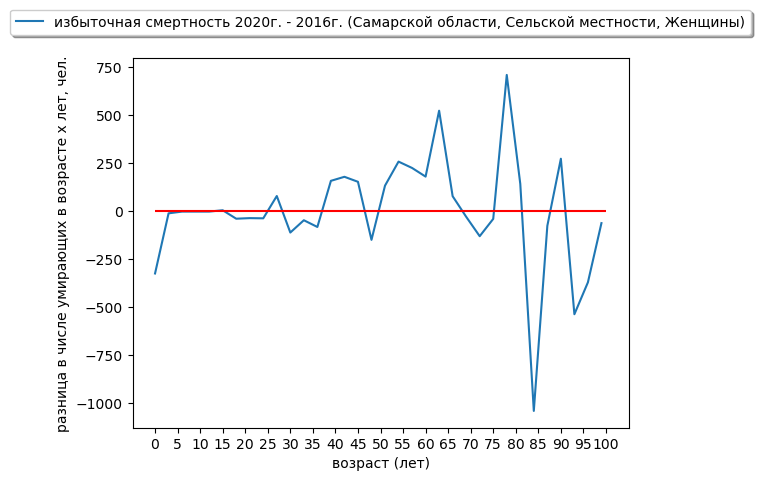

```python
plt.plot(Q1136LF.age[::3], Q1136LF.d_2020[::3] - Q1136LF.d_2016[::3], label='избыточная смертность 2020г. - 2016г. (Самарской области, Сельской местности, Женщины)')
plt.legend(loc='upper center', bbox_to_anchor=(0.5, 1.15),ncol=3, fancybox=True, shadow=True)
plt.xticks(np.arange(min(Q1136LF.age), max(Q1136LF.age)+1, 5))
plt.xlabel('возраст (лет)')
plt.ylabel('разница в числе умирающих в возрасте х лет, чел.')
plt.hlines(y=0,xmin=0,xmax=100, color = 'r')
plt.show()
```

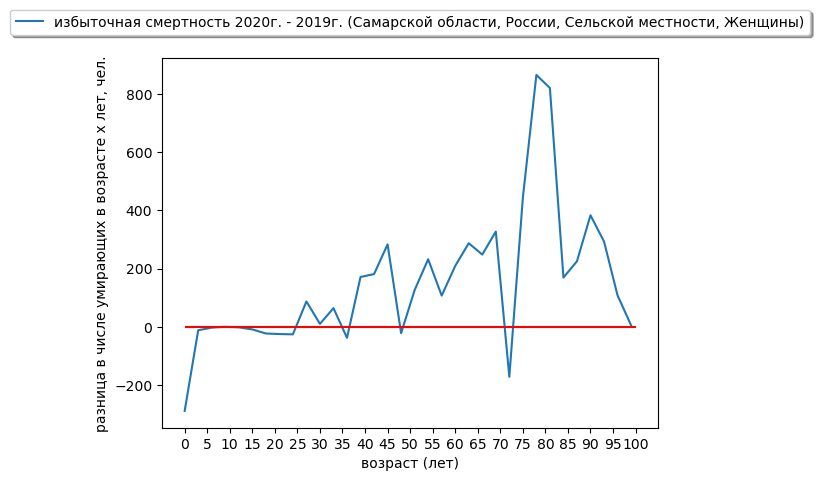

```python
plt.plot(Q1136LF.age[::3], Q1136LF.d_2020[::3] - QLF.d_2019[::3], label='избыточная смертность 2020г. - 2019г. (Самарской области, России, Сельской местности, Женщины)')
plt.legend(loc='upper center', bbox_to_anchor=(0.5, 1.15),ncol=3, fancybox=True, shadow=True)
plt.xticks(np.arange(min(Q1136LF.age), max(Q1136LF.age)+1, 5))
plt.xlabel('возраст (лет)')
plt.ylabel('разница в числе умирающих в возрасте х лет, чел.')
plt.hlines(y=0,xmin=0,xmax=100, color = 'r')
plt.show()
```

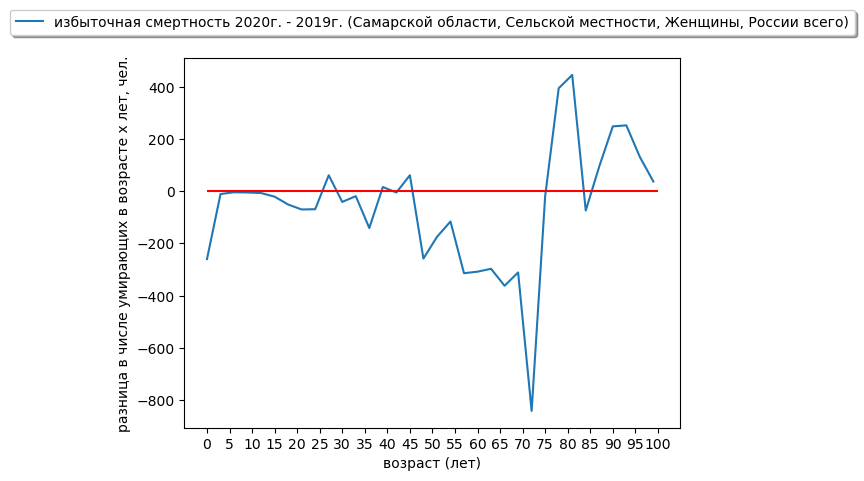

```python
plt.plot(Q1136LF.age[::3], Q1136LF.d_2020[::3] - Q.d_2019[::3], label='избыточная смертность 2020г. - 2019г. (Самарской области, Сельской местности, Женщины, России всего)')
plt.legend(loc='upper center', bbox_to_anchor=(0.5, 1.15),ncol=3, fancybox=True, shadow=True)
plt.xticks(np.arange(min(Q1136LF.age), max(Q1136LF.age)+1, 5))
plt.xlabel('возраст (лет)')
plt.ylabel('разница в числе умирающих в возрасте х лет, чел.')
plt.hlines(y=0,xmin=0,xmax=100, color = 'r')
plt.show()
```

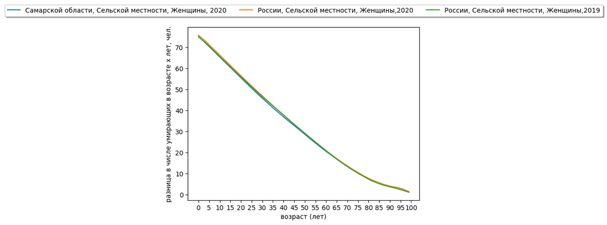

```python
plt.plot(Q1136LF.age[::3], Q1136LF.e_2020[::3], label='Самарской области, Сельской местности, Женщины, 2020')
plt.plot(Q1136LF.age[::3], QLF.e_2020[::3], label='России, Сельской местности, Женщины,2020')
plt.plot(Q1136LF.age[::3], QLF.e_2019[::3], label='России, Сельской местности, Женщины,2019')
plt.legend(loc='upper center', bbox_to_anchor=(0.5, 1.15),ncol=3, fancybox=True, shadow=True)
plt.xticks(np.arange(min(Q1136LF.age), max(Q1136LF.age)+1, 5))
plt.xlabel('возраст (лет)')
plt.ylabel('разница в числе умирающих в возрасте х лет, чел.')
plt.show()
```

[figure not shown]

```python
plt.plot(Q1136LF.age[::3], QLF.e_2019[::3]-Q1136LF.e_2020[::3], label='разница продолжительности жизни 2020г. - 2019г. (Самарской области, России, Сельской местности, Женщины)')
plt.legend(loc='upper center', bbox_to_anchor=(0.5, 1.15),ncol=3, fancybox=True, shadow=True)
plt.xticks(np.arange(min(Q1136LF.age), max(Q1136LF.age)+1, 5))
plt.xlabel('возраст (лет)')
plt.ylabel('разница в продолжительность жизни для возраста x')
plt.hlines(y=0,xmin=0,xmax=100, color = 'r')
plt.show()
```

### Часть II. Актуарная

вариант k = 1 r = 1

возрастной интервал исследования от 20 до 82 лет

срок договоров = 12 годам, доходность 𝑖 = 3.5%

```python
Q1136LF.head(101)
```

|  | age | l_1994 | d_1994 | q_1994 | e_1994 | l_2007 | d_2007 | q_2007 | e_2007 | l_2013 | ... | q_2013 | e_2013 | l_2016 | d_2016 | q_2016 | e_2016 | l_2020 | d_2020 | q_2020 | e_2020 |
| --- | --- | --- | --- | --- | --- | --- | --- | --- | --- | --- | --- | --- | --- | --- | --- | --- | --- | --- | --- | --- | --- |
| 0 | 0 | 100000 | 1085 | 0.01085 | 71.900870 | 100000 | 636 | 0.006361 | 72.040310 | 100000 | ... | 0.007379 | 74.919360 | 100000 | 553 | 0.005532 | 76.165070 | 100000 | 227 | 0.002268 | 75.128110 |
| 1 | 1 | 98915 | 165 | 0.00167 | 71.684067 | 99364 | 34 | 0.000339 | 71.498219 | 99262 | ... | 0.000553 | 74.472658 | 99447 | 25 | 0.000255 | 75.585825 | 99773 | 12 | 0.000117 | 74.297901 |
| 2 | 2 | 98750 | 75 | 0.00076 | 70.803008 | 99330 | 34 | 0.000339 | 70.522521 | 99207 | ... | 0.000553 | 73.513668 | 99422 | 25 | 0.000255 | 74.604705 | 99761 | 12 | 0.000117 | 73.306778 |
| 3 | 3 | 98675 | 70 | 0.00071 | 69.856443 | 99296 | 34 | 0.000339 | 69.546497 | 99152 | ... | 0.000553 | 72.554169 | 99397 | 25 | 0.000255 | 73.623344 | 99749 | 12 | 0.000117 | 72.315537 |
| 4 | 4 | 98605 | 42 | 0.00043 | 68.905679 | 99262 | 34 | 0.000339 | 68.570148 | 99097 | ... | 0.000179 | 71.594160 | 99372 | 25 | 0.000255 | 72.641740 | 99737 | 12 | 0.000117 | 71.324178 |
| ... | ... | ... | ... | ... | ... | ... | ... | ... | ... | ... | ... | ... | ... | ... | ... | ... | ... | ... | ... | ... | ... |
| 96 | 96 | 1022 | 386 | 0.37812 | 1.856164 | 1191 | 466 | 0.391419 | 1.840890 | 2763 | ... | 0.347168 | 2.039993 | 3792 | 1098 | 0.289529 | 2.371308 | 3183 | 726 | 0.228137 | 2.654571 |
| 97 | 97 | 636 | 260 | 0.40882 | 1.679245 | 725 | 284 | 0.391419 | 1.702759 | 1804 | ... | 0.318238 | 1.858647 | 2694 | 674 | 0.250049 | 2.134001 | 2457 | 450 | 0.183333 | 2.291209 |
| 98 | 98 | 376 | 166 | 0.44105 | 1.494681 | 441 | 173 | 0.391419 | 1.477324 | 1230 | ... | 0.385251 | 1.492683 | 2020 | 710 | 0.351416 | 1.679208 | 2007 | 723 | 0.360000 | 1.692825 |
| 99 | 99 | 210 | 100 | 0.47468 | 1.280952 | 268 | 105 | 0.391419 | 1.108209 | 756 | ... | 0.385251 | 1.115079 | 1310 | 238 | 0.181855 | 1.318321 | 1284 | 174 | 0.135136 | 1.364486 |
| 100 | 100 | 110 | 56 | 0.50956 | 0.990909 | 163 | 163 | 1.000000 | 0.500000 | 465 | ... | 1.000000 | 0.500000 | 1072 | 1072 | 1.000000 | 0.500000 | 1110 | 1110 | 1.000000 | 0.500000 |

101 rows × 21 columns

Создаем таблицу смертности с Коммутационными функциями для Самарской области, Сельской местности, Женщины, 2020 года

```python
table = Q1136LF.get(['age','l_2020', 'd_2020', 'q_2020', 'e_2020']).copy()
table.columns = ['age','l', 'd', 'q', 'e']
table.head(101)
```

|  | age | l | d | q | e |
| --- | --- | --- | --- | --- | --- |
| 0 | 0 | 100000 | 227 | 0.002268 | 75.128110 |
| 1 | 1 | 99773 | 12 | 0.000117 | 74.297901 |
| 2 | 2 | 99761 | 12 | 0.000117 | 73.306778 |
| 3 | 3 | 99749 | 12 | 0.000117 | 72.315537 |
| 4 | 4 | 99737 | 12 | 0.000117 | 71.324178 |
| ... | ... | ... | ... | ... | ... |
| 96 | 96 | 3183 | 726 | 0.228137 | 2.654571 |
| 97 | 97 | 2457 | 450 | 0.183333 | 2.291209 |
| 98 | 98 | 2007 | 723 | 0.360000 | 1.692825 |
| 99 | 99 | 1284 | 174 | 0.135136 | 1.364486 |
| 100 | 100 | 1110 | 1110 | 1.000000 | 0.500000 |

101 rows × 5 columns

```python
interest = 0.035
v = 1/(1+interest)
discounted = []
for i in range(0,102):
    discounted.append(v**(i))
```

```python
D = []
for i in range(0,101):
    D.append(discounted[i]*table.l[i])
```

```python
N = []
for i in range(0,101):
    N.append(sum(D[i:]))
```

```python
C = []
for i in range(0,101):
    C.append(discounted[i+1]*table.d[i])
```

```python
M = []
for i in range(0,101):
    M.append(sum(C[i:]))
```

```python
table.insert(loc=5, column='M', value= M)
table.insert(loc=5, column='C', value= C)
table.insert(loc=5, column='N', value= N)
table.insert(loc=5, column='D', value= D)
```

```python
table.head(22)
```

|  | age | l | d | q | e | D | N | C | M |
| --- | --- | --- | --- | --- | --- | --- | --- | --- | --- |
| 0 | 0 | 100000 | 227 | 0.002268 | 75.128110 | 100000.000000 | 2.692381e+06 | 219.323671 | 8953.309774 |
| 1 | 1 | 99773 | 12 | 0.000117 | 74.297901 | 96399.033816 | 2.592381e+06 | 11.202128 | 8733.986103 |
| 2 | 2 | 99761 | 12 | 0.000117 | 73.306778 | 93127.960979 | 2.495982e+06 | 10.823312 | 8722.783975 |
| 3 | 3 | 99749 | 12 | 0.000117 | 72.315537 | 89967.882948 | 2.402854e+06 | 10.457307 | 8711.960662 |
| 4 | 4 | 99737 | 12 | 0.000117 | 71.324178 | 86915.033464 | 2.312886e+06 | 10.103678 | 8701.503355 |
| 5 | 5 | 99725 | 12 | 0.000117 | 70.332700 | 83965.774065 | 2.225971e+06 | 9.762008 | 8691.399677 |
| 6 | 6 | 99713 | 12 | 0.000117 | 69.341104 | 81116.589746 | 2.142005e+06 | 9.431892 | 8681.637670 |
| 7 | 7 | 99701 | 12 | 0.000117 | 68.349390 | 78364.084771 | 2.060888e+06 | 9.112939 | 8672.205778 |
| 8 | 8 | 99689 | 12 | 0.000117 | 67.357557 | 75704.978628 | 1.982524e+06 | 8.804772 | 8663.092839 |
| 9 | 9 | 99677 | 12 | 0.000117 | 66.365606 | 73136.102115 | 1.906819e+06 | 8.507026 | 8654.288068 |
| 10 | 10 | 99665 | 12 | 0.000117 | 65.373536 | 70654.393568 | 1.833683e+06 | 8.219349 | 8645.781042 |
| 11 | 11 | 99653 | 12 | 0.000117 | 64.381348 | 68256.895210 | 1.763029e+06 | 7.941400 | 8637.561693 |
| 12 | 12 | 99641 | 12 | 0.000117 | 63.389042 | 65940.749625 | 1.694772e+06 | 7.672850 | 8629.620294 |
| 13 | 13 | 99629 | 19 | 0.000186 | 62.396616 | 63703.196353 | 1.628831e+06 | 11.737854 | 8621.947444 |
| 14 | 14 | 99610 | 19 | 0.000186 | 61.408423 | 61537.244129 | 1.565128e+06 | 11.340922 | 8610.209590 |
| 15 | 15 | 99591 | 19 | 0.000186 | 60.420043 | 59444.933599 | 1.503591e+06 | 10.957412 | 8598.868668 |
| 16 | 16 | 99572 | 19 | 0.000186 | 59.431477 | 57423.761041 | 1.444146e+06 | 10.586872 | 8587.911256 |
| 17 | 17 | 99553 | 19 | 0.000186 | 58.442724 | 55471.307854 | 1.386722e+06 | 10.228862 | 8577.324384 |
| 18 | 18 | 99534 | 19 | 0.000186 | 57.453785 | 53585.237664 | 1.331251e+06 | 9.882958 | 8567.095522 |
| 19 | 19 | 99515 | 19 | 0.000186 | 56.464659 | 51763.293529 | 1.277666e+06 | 9.548752 | 8557.212564 |
| 20 | 20 | 99496 | 19 | 0.000186 | 55.475346 | 50003.295237 | 1.225902e+06 | 9.225847 | 8547.663813 |
| 21 | 21 | 99477 | 19 | 0.000186 | 54.485846 | 48303.136701 | 1.175899e+06 | 8.913862 | 8538.437965 |

Eдиновременная (A) и ежегодная (P) нетто-ставка по договору пожизненного страхования (выплаты в конце года)

```python
A = []
for i in range(20,83):
    A.append(table.M[i]/table.D[i])
```

```python
P = []
for i in range(20,83):
    P.append(table.M[i]/table.N[i])
```

Eдиновременная (A_x_n1) и ежегодная (P_x_n1) нетто-ставка по договору cтрахование на дожитие на срок 12 лет

```python
A_x_n1 = []
for i in range(20,83):
    A_x_n1.append(table.D[i+12]/table.D[i])
```

```python
P_x_n1 = []
for i in range(20,83):
    P_x_n1.append(table.D[i+12]/(table.N[i]-table.N[i+12]))
```

Eдиновременная (_A_x1_n) и ежегодная (_P_x1_n) нетто-ставка по договору cтрахования жизни на срок 12 лет (выплаты сразу после смерти)

```python
_A_x1_n = []
for i in range(20,83):
    _A_x1_n.append((interest/np.log(1+interest))*((table.M[i]-table.M[i+12])/table.D[i]))
```

```python
_P_x1_n = []
for i in range(20,83):
    _P_x1_n.append((interest/np.log(1+interest))*((table.M[i]-table.M[i+12])/(table.N[i]-table.N[i+12])))
```

Eдиновременная (_A_x_n) и ежегодная (_P_x_n) нетто-ставка по договору смешанного страхования жизни на 12 лет, в случае смерти выплаты сразу

```python
_A_x_n = []
for i in range(0,63):
    _A_x_n.append(_A_x1_n[i]+A_x_n1[i])
```

```python
_P_x_n = []
for i in range(0,63):
    _P_x_n.append(_P_x1_n[i]+P_x_n1[i])
```

Eдиновременная (A_x1_n) и ежегодная (P_x1_n) нетто-ставка по договору cтрахования жизни на срок 12 лет (выплаты в конце года)

```python
A_x1_n = []
for i in range(20,83):
    A_x1_n.append(((table.M[i]-table.M[i+12])/table.D[i]))
```

```python
P_x1_n = []
for i in range(20,83):
    P_x1_n.append((table.M[i]-table.M[i+12])/(table.N[i]-table.N[i+12]))
```

Eдиновременная (A_x_n) и ежегодная (P_x_n) нетто-ставка по договору смешанного страхования жизни на 12 лет, в случае смерти выплаты в конце года

```python
A_x_n = []
for i in range(0,63):
    A_x_n.append(A_x1_n[i]+A_x_n1[i])
```

```python
P_x_n = []
for i in range(0,63):
    P_x_n.append(P_x1_n[i]+P_x_n1[i])
```

Создаем dataframe с посчитанными нетто-ставками для всех видов договоров на срок 12 лет с i = 0.035

```python
age = list(range(20,83))
data = {'age': age, 'A': A, 'P': P, 'A_x_n1': A_x_n1, 'P_x_n1': P_x_n1, 'A_x1_n': A_x1_n,
        'P_x1_n': P_x1_n, '_A_x1_n': _A_x1_n, '_P_x1_n': _P_x1_n, 'A_x_n': A_x_n,
        'P_x_n': P_x_n, '_A_x_n': _A_x_n, '_P_x_n': _P_x_n}

contracts = pd.DataFrame(data)
```

```python
contracts
```

|  | age | A | P | A_x_n1 | P_x_n1 | A_x1_n | P_x1_n | _A_x1_n | _P_x1_n | A_x_n | P_x_n | _A_x_n | _P_x_n |
| --- | --- | --- | --- | --- | --- | --- | --- | --- | --- | --- | --- | --- | --- |
| 0 | 20 | 0.170942 | 0.006973 | 0.655045 | 0.065654 | 0.007559 | 0.000758 | 0.007690 | 0.000771 | 0.662604 | 0.066411 | 0.662736 | 0.066425 |
| 1 | 21 | 0.176768 | 0.007261 | 0.653208 | 0.065508 | 0.009596 | 0.000962 | 0.009763 | 0.000979 | 0.662805 | 0.066471 | 0.662971 | 0.066488 |
| 2 | 22 | 0.182799 | 0.007564 | 0.651836 | 0.065424 | 0.011240 | 0.001128 | 0.011436 | 0.001148 | 0.663076 | 0.066552 | 0.663272 | 0.066571 |
| 3 | 23 | 0.188936 | 0.007877 | 0.650222 | 0.065317 | 0.013139 | 0.001320 | 0.013368 | 0.001343 | 0.663361 | 0.066637 | 0.663590 | 0.066660 |
| 4 | 24 | 0.195289 | 0.008207 | 0.649126 | 0.065275 | 0.014587 | 0.001467 | 0.014840 | 0.001492 | 0.663713 | 0.066742 | 0.663967 | 0.066767 |
| ... | ... | ... | ... | ... | ... | ... | ... | ... | ... | ... | ... | ... | ... |
| 58 | 78 | 0.745996 | 0.099317 | 0.176521 | 0.025897 | 0.592976 | 0.086994 | 0.603293 | 0.088507 | 0.769496 | 0.112890 | 0.779814 | 0.114404 |
| 59 | 79 | 0.757065 | 0.105383 | 0.153720 | 0.023249 | 0.622688 | 0.094176 | 0.633522 | 0.095815 | 0.776408 | 0.117425 | 0.787242 | 0.119064 |
| 60 | 80 | 0.770477 | 0.113517 | 0.130074 | 0.020554 | 0.655928 | 0.103651 | 0.667341 | 0.105454 | 0.786001 | 0.124205 | 0.797414 | 0.126009 |
| 61 | 81 | 0.780759 | 0.120427 | 0.102629 | 0.016784 | 0.690594 | 0.112940 | 0.702610 | 0.114905 | 0.793223 | 0.129724 | 0.805239 | 0.131689 |
| 62 | 82 | 0.790190 | 0.127360 | 0.085619 | 0.014503 | 0.714746 | 0.121072 | 0.727183 | 0.123179 | 0.800365 | 0.135575 | 0.812802 | 0.137682 |

63 rows × 13 columns

```python
contracts.to_excel(excel_writer = "contracts.xlsx", index=False)
```

Строим графики для данных договоров

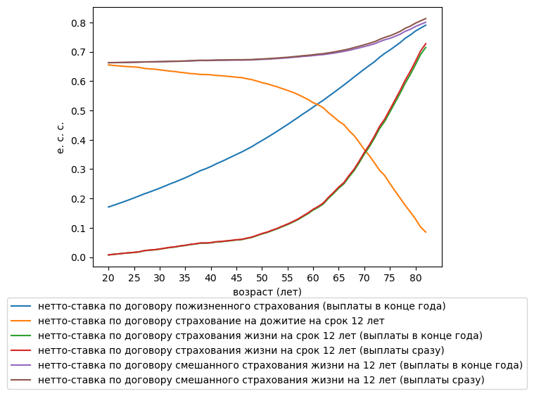

```python
plt.plot(contracts.age, contracts.A, label='нетто-ставка по договору пожизненного страхования (выплаты в конце года)')
plt.plot(contracts.age, contracts.A_x_n1, label='нетто-ставка по договору cтрахование на дожитие на срок 12 лет')
plt.plot(contracts.age, contracts.A_x1_n, label='нетто-ставка по договору cтрахования жизни на срок 12 лет (выплаты в конце года)')
plt.plot(contracts.age, contracts._A_x1_n, label='нетто-ставка по договору cтрахования жизни на срок 12 лет (выплаты сразу)')
plt.plot(contracts.age, contracts.A_x_n, label='нетто-ставка по договору смешанного страхования жизни на 12 лет (выплаты в конце года)')
plt.plot(contracts.age, contracts._A_x_n, label='нетто-ставка по договору смешанного страхования жизни на 12 лет (выплаты сразу)')
plt.legend(loc='upper center', bbox_to_anchor=(0.5, -0.1))
plt.xticks(np.arange(min(contracts.age), max(contracts.age)+1, 5))
plt.xlabel('возраст (лет)')
plt.ylabel('е. с. с.')
plt.show()
```

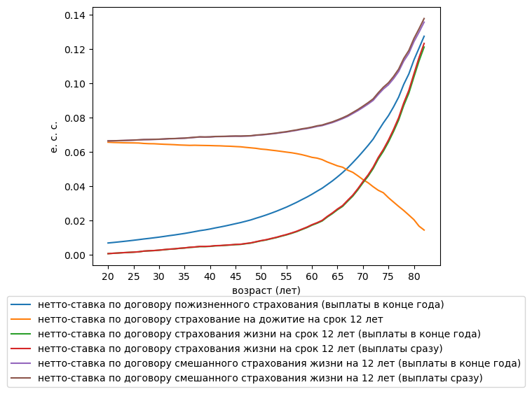

```python
plt.plot(contracts.age, contracts.P, label='нетто-ставка по договору пожизненного страхования (выплаты в конце года)')
plt.plot(contracts.age, contracts.P_x_n1, label='нетто-ставка по договору cтрахование на дожитие на срок 12 лет')
plt.plot(contracts.age, contracts.P_x1_n, label='нетто-ставка по договору cтрахования жизни на срок 12 лет (выплаты в конце года)')
plt.plot(contracts.age, contracts._P_x1_n, label='нетто-ставка по договору cтрахования жизни на срок 12 лет (выплаты сразу)')
plt.plot(contracts.age, contracts.P_x_n, label='нетто-ставка по договору смешанного страхования жизни на 12 лет (выплаты в конце года)')
plt.plot(contracts.age, contracts._P_x_n, label='нетто-ставка по договору смешанного страхования жизни на 12 лет (выплаты сразу)')
plt.legend(loc='upper center', bbox_to_anchor=(0.5, -0.1))
plt.xticks(np.arange(min(contracts.age), max(contracts.age)+1, 5))
plt.xlabel('возраст (лет)')
plt.ylabel('е. с. с.')
plt.show()
```

```python
P_sum = []
for i in range(1,64):
    P_sum.append(sum(contracts.P[:i]))
```

```python
A_sum = []
for i in range(1,64):
    A_sum.append(contracts.A[0])
```

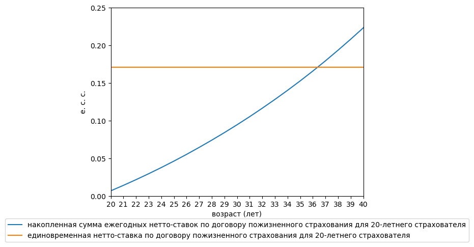

```python
plt.plot(contracts.age, P_sum, label='накопленная сумма ежегодных нетто-ставок по договору пожизненного страхования для 20-летнего страхователя')
plt.plot(contracts.age, A_sum, label='единовременная нетто-ставка по договору пожизненного страхования для 20-летнего страхователя')
plt.legend(loc='upper center', bbox_to_anchor=(0.5, -0.1))
plt.xticks(np.arange(min(contracts.age), max(contracts.age)+1, 1))
plt.xlabel('возраст (лет)')
plt.ylabel('е. с. с.')
plt.xlim(20,40)
plt.ylim(0,0.25)
plt.show()
```